# ME613 - Análise de Regressão

## Diagnóstico do Modelo

## George Box

"All models are wrong but some are useful."

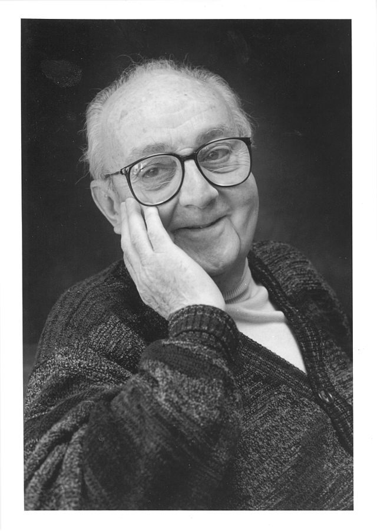

[By DavidMCEddy at en.wikipedia, CC BY-SA 3.0](https://commons.wikimedia.org/w/index.php?curid=14941622)

## Introdução

Como saber se a função de regressão é adequada para explicar a relação entre as variáveis observadas?

- Gráficos
- Testes

> Caso a função de regressão não seja adequada, o que fazer?
- Transformação de variáveis.
- Outro tipo de modelo.

## Diagnósticos para a variável preditora

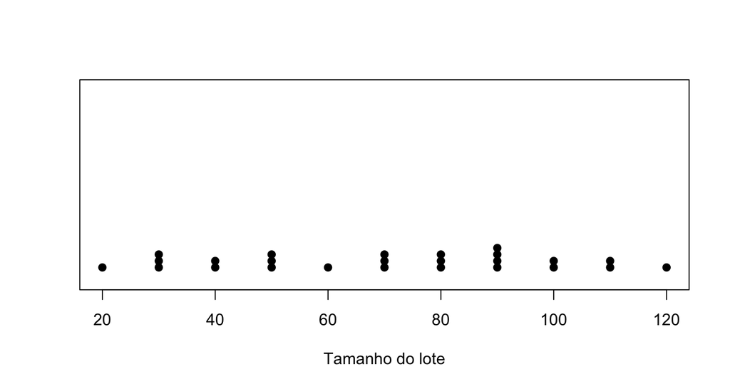

- Quantas observações em cada valor diferente de \(X\)?
- Amplitude dos valores de \(X\).

## Diagnósticos para a variável preditora

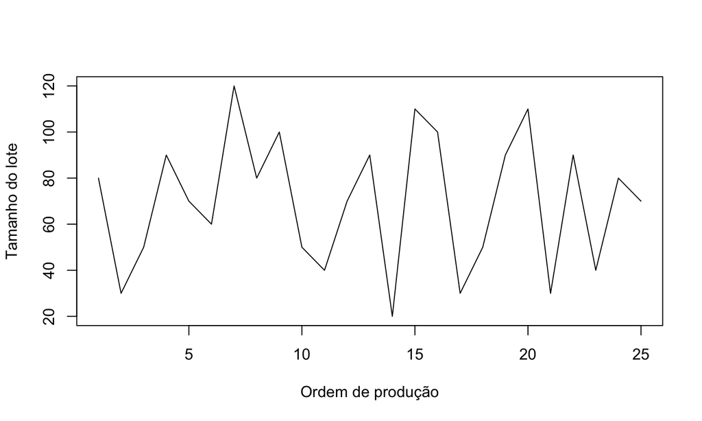

Se as observações são feitas ao longo do tempo, há correlação entre seus valores e o tempo de observação?

## Diagnósticos para a variável preditora

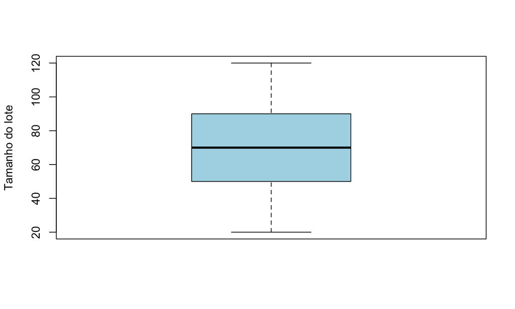

## Resíduos

Gráficos de diagnósticos para \(Y\) não são úteis em análise de regressão, pois a variável resposta é uma função da preditora.

> Os gráficos de diagnósticos são feitos para os resíduos.
- Resíduos:

\[e_i=Y_i-\hat{Y}_i\]

- Erros:

\[\varepsilon_i=Y_i-E(Y_i)\]

Se assumimos \(\varepsilon_i\underset{iid}{\sim}\mathcal{N}(0,\sigma^2)\), esperamos que \(e_i\)'s, os resíduos observados, reflitam as propriedades assumidas para \(\varepsilon_i\)'s.

## Propriedades dos resíduos

- Média dos resíduos:

\[\bar{e}=\frac{\sum_{i=1}^ne_i}{n}=0\]

> Como \(\bar{e}\) é sempre nula, não fornece informação sobre \(E(\varepsilon_i)\).
- Variância dos resíduos:

\[s^2=\frac{\sum_{i=1}^n(e_i-\bar{e})^2}{n-2}=\frac{SQErro}{n-2}=QMErro\]

> Se o modelo é apropriado, \(s^2\) é um estimador não viesado para \(\sigma^2\).

## Propriedades dos resíduos

- Independência: \(e_i\)'s **não são variáveis aleatórias independentes**, pois dependem de \(\hat{Y}_i\), que por sua vez dependem das mesmas estimativas para os parâmetros \(\beta_0\) e \(\beta_1\).

> Quanto maior o número de observações com relação ao número de parâmetros estimados, menor é a dependência dos resíduos (pode ser ignorada).

## Resíduos semi-studentizados

Para detectar outliers, muitas vezes é mais útil observar resíduos padronizados.

> Resíduo semi-studentizado:

\[e_i^*=\frac{e_i}{\sqrt{QME}}\]

## Suposições do modelo estudadas através da análise de resíduos

Podemos utilizar análise de resíduos para verificar se:

1. a função de regressão não é linear
2. erros não possuem variância constante (heterocedasticidade)
3. erros não são independentes
4. o modelo ajustado é adequado, com exceção de algumas observações outliers
5. erros não seguem distribuição normal
6. uma ou mais variáveis preditoras foram omitidas no modelo

## Análise de Resíduos: gráficos

- Resíduos x Variável preditora
- Resíduos absolutos x Variável preditora
- Resíduos x Valores ajustados (\(\hat{Y}\))
- Resíduos ao longo do tempo/em sequência
- Resíduos X Variável preditora não incluída no modelo
- Boxplot dos resíduos
- Gráfico de probabilidade normal dos resíduos

## Exemplo: Preço do diamante

Preços de diamantes (dólares de Singapura) e peso em quilates (1 quilate = 0.2g).

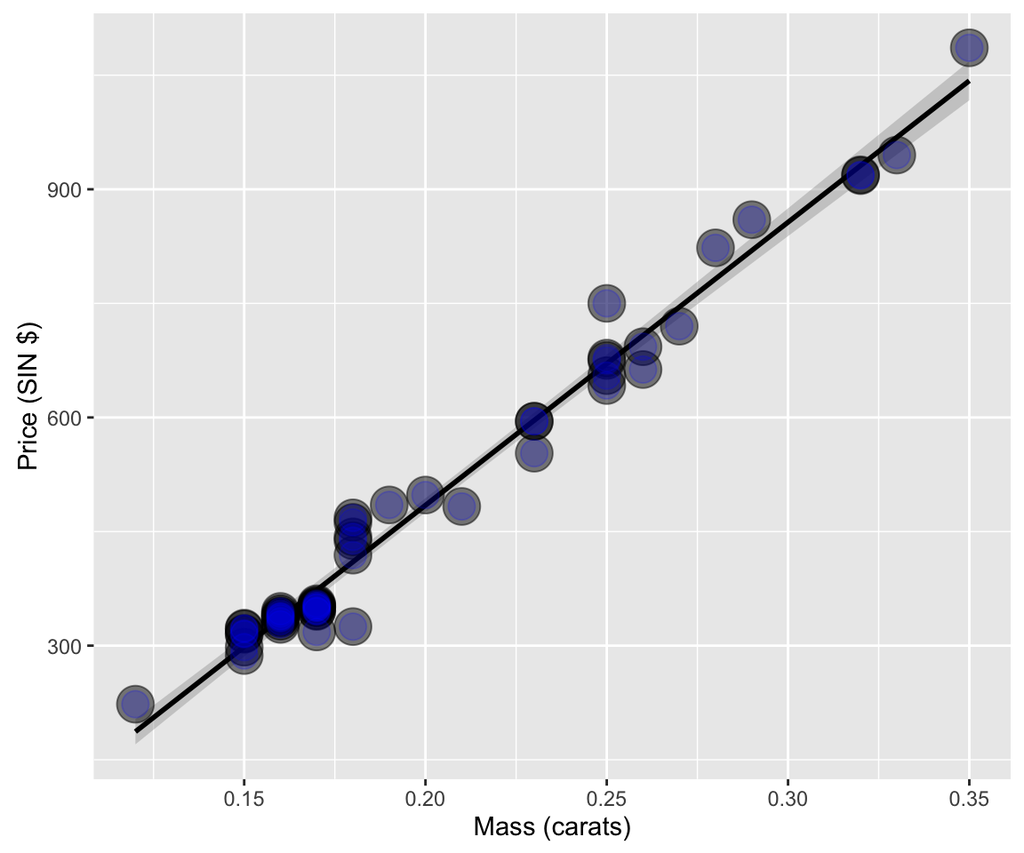

## Exemplo: Preço do diamante

Resíduos: comprimento das linhas vermelhas, mantendo o sinal.

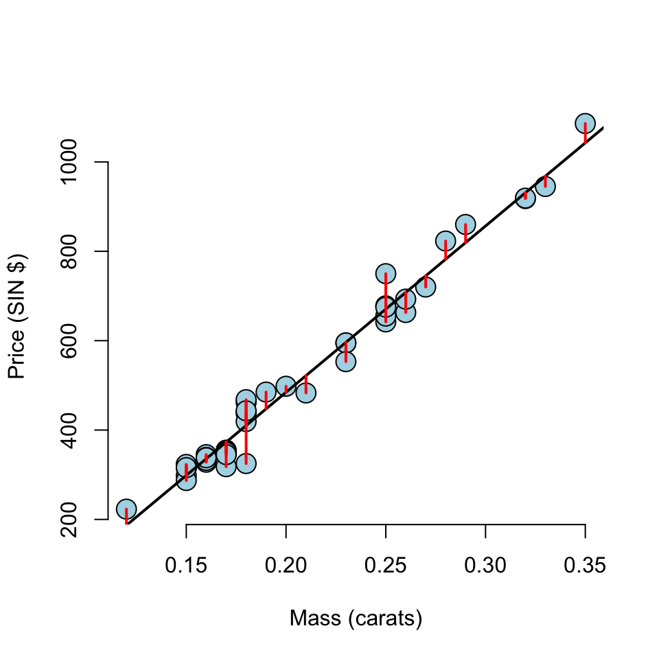

## Exemplo: Preço do diamante

Resíduos X Variável preditora

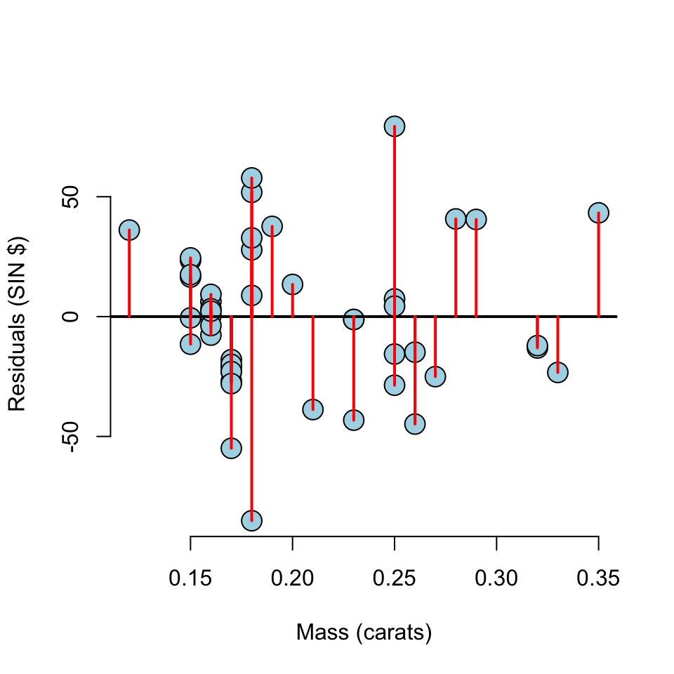

## Exemplo: Preço do diamante

Resíduos X ordem

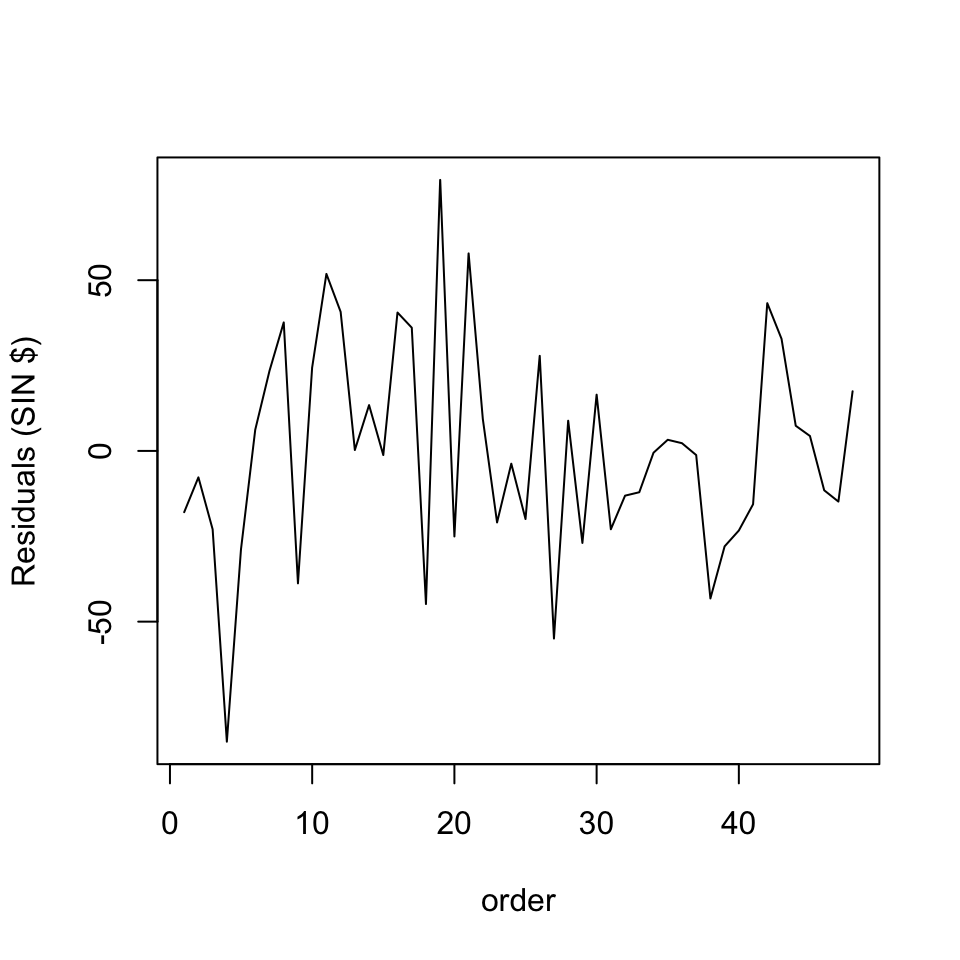

## Exemplo: Preço do diamante

Boxplot dos resíduos

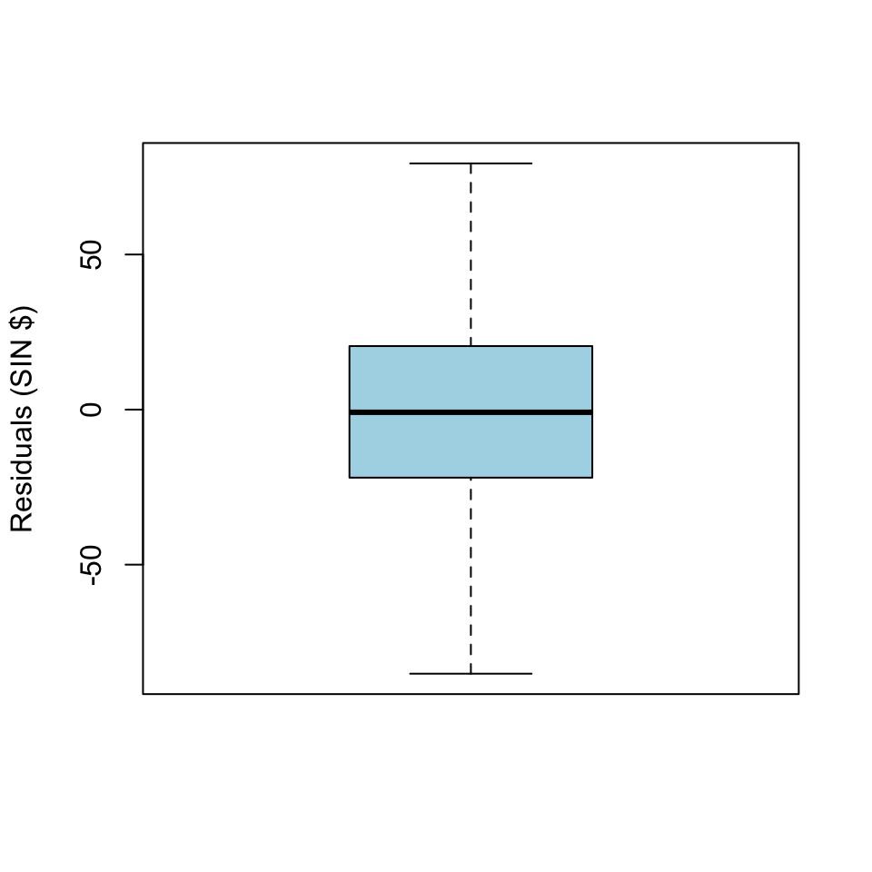

## Exemplo: Preço do diamante

Gráfico de normalidade dos resíduos

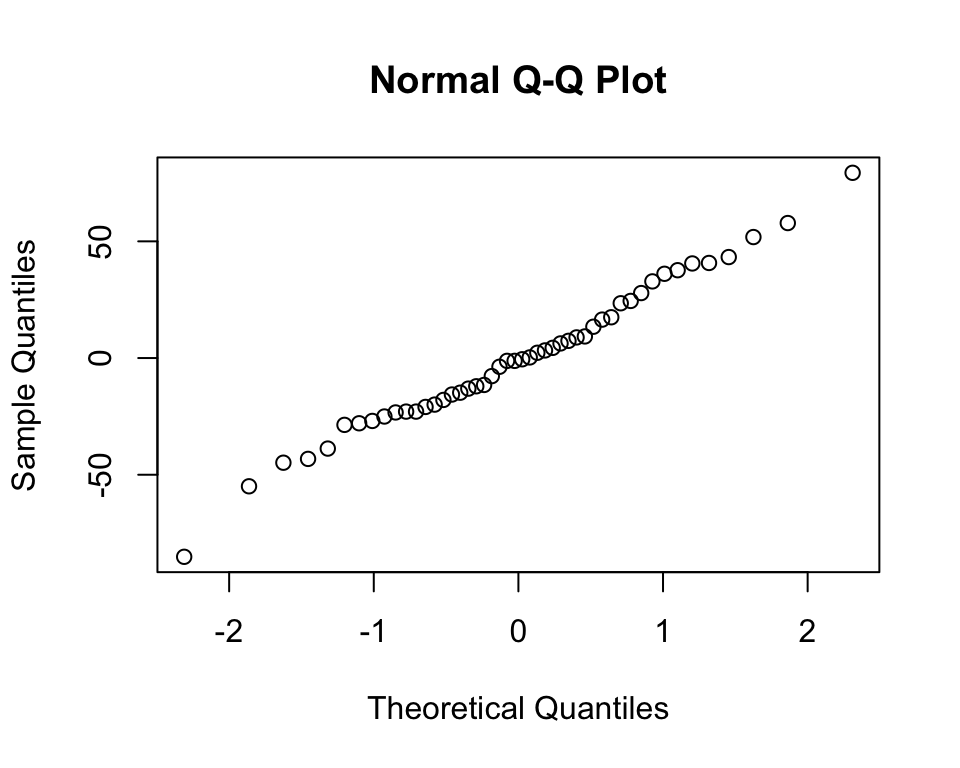

(ver Kutner pag 110)

## Exemplo: não-linearidade

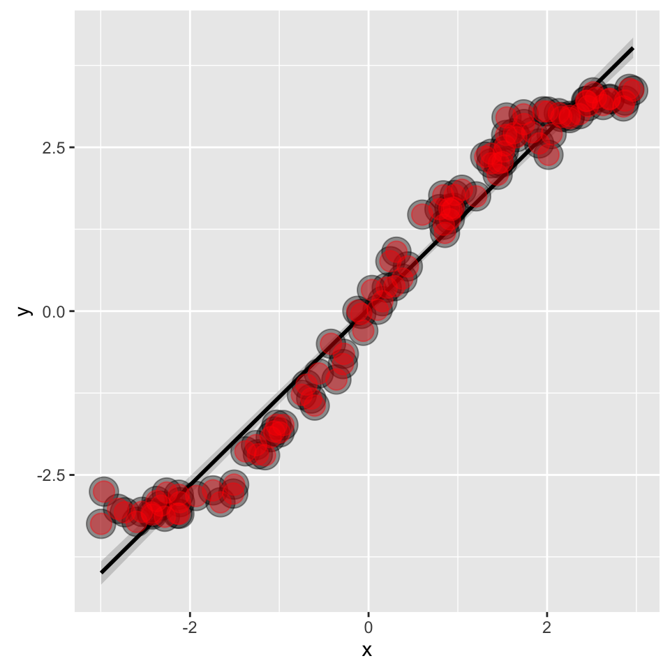

## Exemplo: não-linearidade

Resíduos X Variável preditora

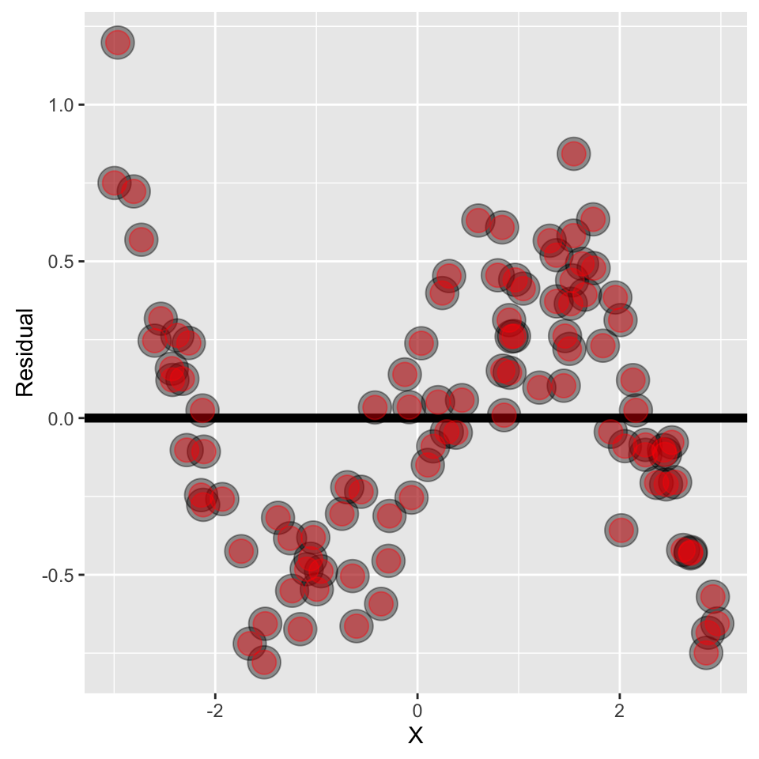

## Exemplo: heterocedasticidade

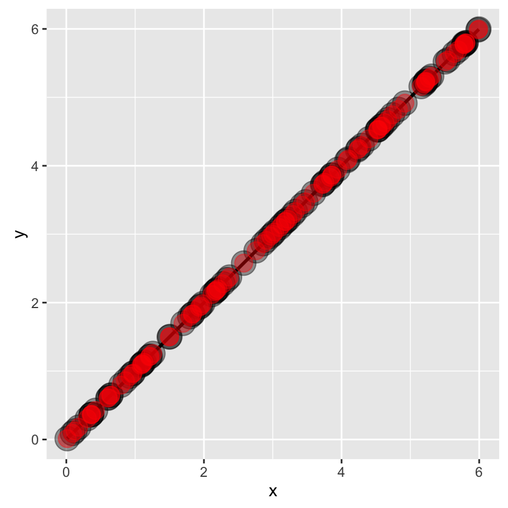

## Exemplo: heterocedasticidade

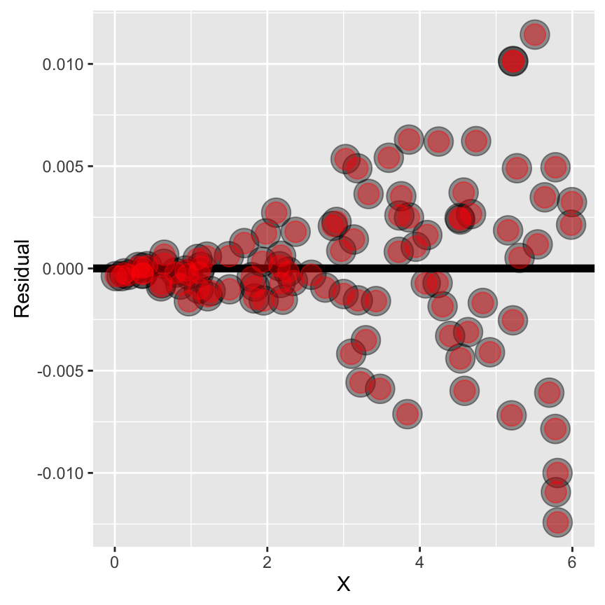

## Análise de Resíduos: testes de hipóteses

Além de gráficos, podemos também utilizar testes de hipóteses estatísticos para avaliar algumas suposições do modelo.

## Teste de correlação para normalidade

Calcular coeficiente de correlação entre \(e_i\) e seus valores esperados, segundo a distribuição normal

> Quanto maior a correlação, maior o indício de normalidade dos resíduos.

> Detalhes sobre o teste: [Looney & Gulledge (1985) - Use of the Correlation Coefficient with Normal Probability Plots](http://www.jstor.org/stable/2683917)

## Teste de correlação para normalidade

Calcular a correlação entre os resíduos ordenados e

\[r=\{r_1,r_2,\ldots,r_k\ldots,r_n\}\]

em que \(r_k\) é o valor esperado do \(k\)-ésimo resíduos, segundo a suposição de normalidades.

\[r_k\approx \sqrt{QME}\left[z\left(\frac{k-0.375}{n+0.25} \right) \right]\]

\(z(A)\) é o \(A\times 100\) percentil da distribuição normal padrão.

> Obs: Outro teste conhecido: [Teste de Shapiro-Wilks](http://www.portalaction.com.br/inferencia/64-teste-de-shapiro-wilk).

## Teste de homocedasticidade: Brown-Forsythe

- Não depende da suposição de normalidade
- Aplicável no caso de regressão linear simples quando a variância do erro aumenta ou decresce com a variável preditora \(X\).
- Tamanho amostral grande o suficiente para que possamos assumir que os resíduos são independentes.
- Idéia parecida com um teste-t para duas amostras.

## Teste de homocedasticidade: Brown-Forsythe

- \(X\) é dividida em \(X_1\) (valores mais baixos de \(X\)) e \(X_2\) (valores mais altos de \(X\)). Isto é, temos dois grupos.
- \(e_{i1}\) é o \(i\)-ésimo resíduo para o grupo 1 e \(e_{i2}\) é o \(i\)-ésimo resíduo para o grupo 2.
- \(n_j\) é o número de observações no grupo \(j\)
- \(n=n_1+n_2\).
- \(\tilde{e}_j\) é a mediana dos resíduos do grupo \(j\).
- \(d_{i1}=| e_{i1}-\tilde{e}_1|\quad\quad d_{i2}=| e_{i2}-\tilde{e}_2|\)

## Teste de homocedasticidade: Brown-Forsythe

Estatística do teste:

\[t^*_{BF}=\frac{\bar{d}_1-\bar{d}_2}{s\sqrt{\frac{1}{n_1}+\frac{1}{n_2}}}\]

\[s^2=\frac{\sum(d_{i1}-\bar{d}_1)^2+\sum(d_{i2}-\bar{d}_2)^2}{n-2}\]

> Se a variância é constante e \(n_1\) e \(n_2\) grandes o suficiente, então \(t^*_{BF}\) segue distribuição \(t\) com \(n-2\) graus de liberdade.

> Valores altos de \(t^*_{BF}\) indicam heterocedasticidade.

## Exemplo: Toluca

```r
data <- read.table("./dados/CH01TA01.txt")
x = data[,1]
y = data[,2]
ind1 = which(x<80)
ind2 = which(x>=80)
fit = lm(y~x)
resi = fit$resi
resi1 = resi[ind1]
resi2 = resi[ind2]
d1 = abs(resi1-median(resi1))
d2 = abs(resi2-median(resi2))
t.test(d1,d2)
```

## Exemplo: Toluca

```
##
##  Welch Two Sample t-test
##
## data:  d1 and d2
## t = 1.3215, df = 22.999, p-value = 0.1993
## alternative hypothesis: true difference in means is not equal to 0
## 95 percent confidence interval:
##  -9.253335 41.982809
## sample estimates:
## mean of x mean of y
##  44.81507  28.45034
```

Não rejeitamos \(H_0\), isto é, não obtemos evidências para rejeitar a hipótese de homocedasticidade dos erros.

## Teste de homocedasticidade: Breusch-Pagan

> Assume que \(\varepsilon_i\sim\mathcal{N}(0,\sigma_i^2)\).

> O seguinte modelo é assumido:

\[\log_e\sigma_i^2=\gamma_0+\gamma_1X_i\]

> Se \(\gamma_1=0\) temos homocedasticidade.

> \(H_0\): \(\gamma_1=0\) vs \(H_1\): \(\gamma_1\neq0\).

## Teste de homocedasticidade: Breusch-Pagan

Estatística do teste:

\[X^2_{BP}=\frac{\frac{SQRq}{2}}{\left(\frac{SQE}{n}\right)^2}\]

em que \(SQRq\) é a soma de quadrados da regressão de \(e_i^2\) em \(X\) e \(SQE\) é a soma de quadrados do erro da regressão de \(Y\) em \(X\).

Sob \(H_0\), \(X^2_{BP}\sim\chi^2_1\).

## Exemplo: Toluca

```r
fit = lm(y~x)
resi = fit$resi
fit2 = lm(resi^2~x)
a1 <- anova(fit)
a2 <- anova(fit2)
estatistica <- (a2$`Sum Sq`[1]/2)/((a1$`Sum Sq`[2]/length(y))^2)
```

## Exemplo: Toluca

```
## Analysis of Variance Table
##
## Response: y
##           Df Sum Sq Mean Sq F value    Pr(>F)
## x          1 252378  252378  105.88 4.449e-10 ***
## Residuals 23  54825    2384
## ---
## Signif. codes:  0 '***' 0.001 '**' 0.01 '*' 0.05 '.' 0.1 ' ' 1
```

```
## Analysis of Variance Table
##
## Response: resi^2
##           Df    Sum Sq Mean Sq F value Pr(>F)
## x          1   7896142 7896142  1.0914  0.307
## Residuals 23 166395896 7234604
```

```
## [1] 0.8209192
```

## Teste de homocedasticidade: Breusch-Pagan

Diretamente pelo R:

```r
library('car')
ncvTest(fit)
```

```
## Non-constant Variance Score Test
## Variance formula: ~ fitted.values
## Chisquare = 0.8209192    Df = 1     p = 0.3649116
```

## Teste F para falta de ajuste

Queremos testar se a função de regressão proposta é adequada para os dados.

Suposições: as observações de \(Y|X\) são

- independentes
- seguem distribuição normal
- variância constante \(\sigma^2\)

É preciso que tenhamos mais de uma observação para cada nível de \(X\) (replicações).

## Teste F para falta de ajuste

Suponha que tenhamos \(m\) valores distintos para \(X\)

Para cada valor diferente de \(X\), \(x_j\), temos \(n_j\) observações.

- \(Y_{11},Y_{12},\ldots, Y_{1n_1}\) são \(n_1\) repetições para \(X=x_1\).
- \(Y_{21},Y_{22},\ldots, Y_{2n_2}\) são \(n_2\) repetições para \(X=x_2\).
- \(Y_{m1},Y_{m2},\ldots, Y_{mn_m}\) são \(n_m\) repetições para \(X=x_m\).

\[n=\sum_{j=1}^m\sum_{u=1}^{n_j}1=\sum_{j=1}^mn_j\]

## Teste F para falta de ajuste

Com replicações para cada \(X=x_k\), temos um estimador para \(Var(Y|X=x_k)=\sigma^2\) para todo \(k\).

Por exemplo, quando \(X=x_1\), podemos usar \(Y_{11},Y_{12},\ldots, Y_{1n_1}\) e o seguinte estimador para \(Var(Y|X=x_1)\):

\[\frac{1}{n_1-1}\sum_{j=1}^{n_1}(Y_{1j}-\bar{Y}_1)^2\]

Combinando todas as observações (não apenas as replicações para um dado nível de \(X\)), temos o seguinte estimador para \(\sigma^2\):

\[s_p^2=\frac{\sum_{j=1}^m\sum_{u=1}^{n_j}(Y_{ju}-\bar{Y}_j)^2}{\sum_{j=1}^m(n_j-1)}\]

## Teste F para falta de ajuste

\[SQE_p=\sum_{j=1}^m\sum_{u=1}^{n_j}=(Y_{ju}-\bar{Y}_j)^2\]

com graus de liberdade \(n_p=\sum_{j=1}^m(n_j-1)=\sum_{j=1}^mn_j-m\).

\[QME_{puro}=s_p^2=\frac{\sum_{j=1}^m\sum_{u=1}^{n_j}(Y_{ju}-\bar{Y}_j)^2}{\sum_{j=1}^mn_j-m}\]

## Teste F para falta de ajuste

Relembrando:

\[SQE=\sum_{j=1}^m\sum_{u=1}^{n_j}(Y_{ju}-\hat{Y}_j)^2\]

**Mostre\(^1\)** que a \(SQE\) pode ser particionada da seguinte forma:

\[\sum_{j=1}^m\sum_{u=1}^{n_j}(Y_{ju}-\hat{Y}_j)^2 = \sum_{j=1}^m\sum_{u=1}^{n_j}(Y_{ju}-\bar{Y}_j)^2 + \sum_{j=1}^mn_j(\hat{Y}_j-\bar{Y}_j)^2\]

## Teste F para falta de ajuste

\[\underbrace{\sum_{j=1}^m\sum_{u=1}^{n_j}(Y_{ju}-\hat{Y}_j)^2}_{SQE} = \underbrace{\sum_{j=1}^m\sum_{u=1}^{n_j}(Y_{ju}-\bar{Y}_j)^2}_{SQE_p} + \underbrace{\sum_{j=1}^mn_j(\hat{Y}_j-\bar{Y}_j)^2}_{SQF_a}\]

\(SQE\) é a soma de quadrados dos resíduos, representando a variação em torno da reta.

\(SQE_p\) é a soma de quadrados do erro puro, representando a variação de \(Y\), para \(X\) fixo, independente do modelo (pois utilizamos as replicações).

\(SQF_a\) é a soma de quadrados da falta de ajuste, representando a falta de ajuste do modelo.

## Teste F para falta de ajuste

\(SQE\) é o numerador de \(s^2\) e \(SQE_p\) é o numerador de \(s^2_p\).

Valores relativamente altos de \(SQF_a\) indicam discrepância entre esses dois estimadores e, consequentemente, indicam evidência contra a adequação do modelo de regressão linear simples.

Quanto mais alto o valor de \(SQF_a\), pior é o ajuste do modelo, pois, se o modelo fosse perfeito, teríamos que \(SQF_a=0\).

## Teste F para falta de ajuste

\(H_0\): o MRLS é adequado

\(H_1\): o MRLS não é adequado

Estatística do teste:

\[F^*=\frac{SQF_a/(m-2)}{SQE_p/(n-m)}\overset{\mbox{sob }H_0}{\sim} F_{m-2,n-m}\]

## Teste F para falta de ajuste

| Fonte de Variação | gl | SQ |
| --- | --- | --- |
| Regressão | \(1\) | \(SQReg=\sum_{i=1}^n(\hat{Y}_i-\bar{Y})^2\) |
| Erro | \(n-2\) | \(SQE=\sum_{i=1}^n(Y_i-\hat{Y})^2\) |
| (Falta de ajuste) | \(m-2\) | \(SQF_a=\sum_{j=1}^mn_j(\hat{Y}_j-\bar{Y}_j)^2\) |
| (Erro puro) | \(n-m\) | \(SQE_p=\sum_{j=1}^m\sum_{u=1}^{n_j}(Y_{ju}-\bar{Y}_j)^2\) |
| Total (ajustada) | \(n-1\) | \(SQT=\sum_{i=1}^n(Y_i-\bar{Y})^2\) |

## Exemplo: Agências bancárias

11 agências de um certo banco ofereceram brindes para novos clientes.

Um depósito inicial mínimo era necessário para qualificar para o brinde.

Cada agência especificou o valor do depósito mínimo.

Interesse: valor do depósito mínimo inicial e número de contas que foram abertas na agência.

## Exemplo: Agências bancárias

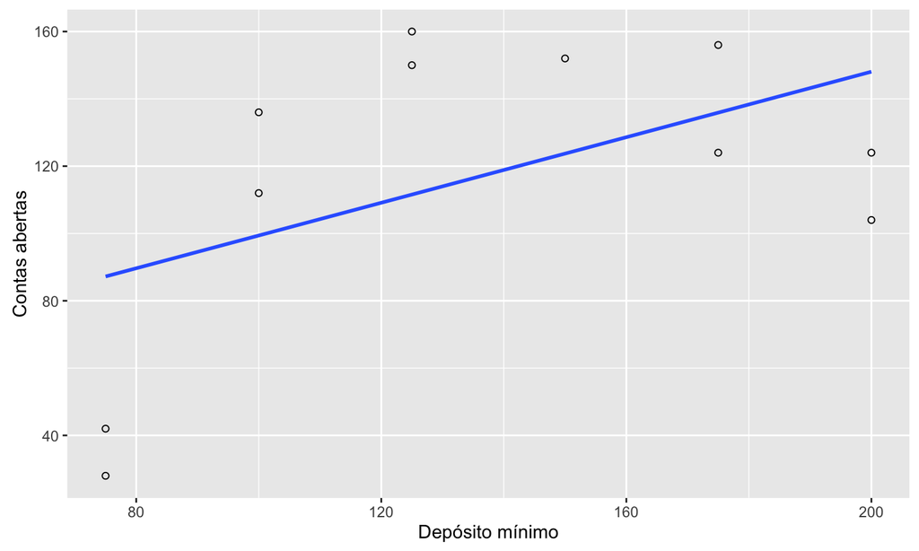

## Exemplo: Agências bancárias

Modelo completo:

\[Y_{ij}=\mu_{j}+\varepsilon_{ij}\]

Temos que \(E(Y_{ij})=\mu_j\), isto é, temos esperança diferente para cada \(X_j\).

## Exemplo: Agências bancárias

```r
Full=lm(y~as.factor(x)-1)
summary(Full)
```

```
##
## Call:
## lm(formula = y ~ as.factor(x) - 1)
##
## Residuals:
##   1   2   3   4   5   6   7   8   9  10  11
##   5 -12  10  -7   0  16   7 -16  -5 -10  12
##
## Coefficients:
##                 Estimate Std. Error t value Pr(>|t|)
## as.factor(x)75     35.00      10.71   3.267 0.022282 *
## as.factor(x)100   124.00      10.71  11.573 8.45e-05 ***
## as.factor(x)125   155.00      10.71  14.466 2.85e-05 ***
## as.factor(x)150   152.00      15.15  10.031 0.000168 ***
## as.factor(x)175   140.00      10.71  13.066 4.68e-05 ***
## as.factor(x)200   114.00      10.71  10.640 0.000127 ***
## ---
## Signif. codes:  0 '***' 0.001 '**' 0.01 '*' 0.05 '.' 0.1 ' ' 1
##
## Residual standard error: 15.15 on 5 degrees of freedom
## Multiple R-squared:  0.9933, Adjusted R-squared:  0.9852
## F-statistic: 123.1 on 6 and 5 DF,  p-value: 2.893e-05
```

## Exemplo: Agências bancárias

Modelo reduzido: reta de regressão.

```r
Reduced=lm(y~x)
summary(Reduced)
```

```
##
## Call:
## lm(formula = y ~ x)
##
## Residuals:
##    Min     1Q Median     3Q    Max
## -59.23 -34.06  12.61  32.44  48.44
##
## Coefficients:
##             Estimate Std. Error t value Pr(>|t|)
## (Intercept)  50.7225    39.3979   1.287     0.23
## x             0.4867     0.2747   1.772     0.11
##
## Residual standard error: 40.47 on 9 degrees of freedom
## Multiple R-squared:  0.2586, Adjusted R-squared:  0.1762
## F-statistic: 3.139 on 1 and 9 DF,  p-value: 0.1102
```

\(s=40.47\) enquanto que, usando o modelo anterior, temos que \(s_e=15.15\).

## Exemplo: Agências bancárias

```r
Reduced=lm(y~x)
Full=lm(y~as.factor(x)-1)
anova(Reduced, Full)
```

```
## Analysis of Variance Table
##
## Model 1: y ~ x
## Model 2: y ~ as.factor(x) - 1
##   Res.Df   RSS Df Sum of Sq      F   Pr(>F)
## 1      9 14742
## 2      5  1148  4     13594 14.801 0.005594 **
## ---
## Signif. codes:  0 '***' 0.001 '**' 0.01 '*' 0.05 '.' 0.1 ' ' 1
```

Estatística do teste:

\[F^*=\frac{SQF_a/(m-2)}{SQE_p/(n-m)}\overset{\mbox{sob }H_0}{\sim} F_{m-2,n-m}=F_{4,5}\]

## Exemplo: Agências bancárias

\[F^*_{obs}=\frac{[SQE(Reduced)-SQE(Full)]/4}{SQE(Full)/5}=\frac{1.3593571\times 10^{4}/4}{1148/5}=14.8\]

valor de p: 0.0055938.

Valor crítico para \(\alpha=0.05\): 5.19

## Exemplo: Ligas de cobre e níquel

13 ligas de cobre e níquel, mas quantidades diferentes de ferro.

As ligas foram submersas em água do mar por 60 dias e a perda de peso devido à corrosão foi anotada em miligramas por decímetro quadrado por dia.

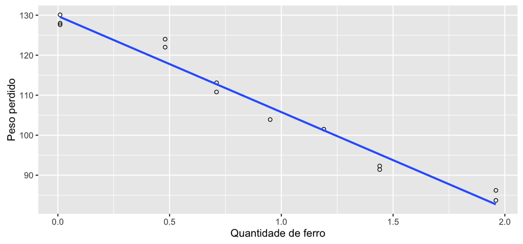

## Exemplo: Ligas de cobre e níquel

```
##
## Call:
## lm(formula = loss ~ Fe, data = corrosion)
##
## Residuals:
##     Min      1Q  Median      3Q     Max
## -3.7980 -1.9464  0.2971  0.9924  5.7429
##
## Coefficients:
##             Estimate Std. Error t value Pr(>|t|)
## (Intercept)  129.787      1.403   92.52  < 2e-16 ***
## Fe           -24.020      1.280  -18.77 1.06e-09 ***
## ---
## Signif. codes:  0 '***' 0.001 '**' 0.01 '*' 0.05 '.' 0.1 ' ' 1
##
## Residual standard error: 3.058 on 11 degrees of freedom
## Multiple R-squared:  0.9697, Adjusted R-squared:  0.967
## F-statistic: 352.3 on 1 and 11 DF,  p-value: 1.055e-09
```

## Exemplo: Ligas de cobre e níquel

```
##
## Call:
## lm(formula = loss ~ factor(Fe) - 1, data = corrosion)
##
## Residuals:
##     Min      1Q  Median      3Q     Max
## -1.2500 -0.9667  0.0000  1.0000  1.5333
##
## Coefficients:
##                Estimate Std. Error t value Pr(>|t|)
## factor(Fe)0.01 128.5667     0.8090  158.91 4.19e-12 ***
## factor(Fe)0.48 123.0000     0.9909  124.13 1.84e-11 ***
## factor(Fe)0.71 111.9500     0.9909  112.98 3.24e-11 ***
## factor(Fe)0.95 103.9000     1.4013   74.15 4.05e-10 ***
## factor(Fe)1.19 101.5000     1.4013   72.43 4.66e-10 ***
## factor(Fe)1.44  91.8500     0.9909   92.70 1.06e-10 ***
## factor(Fe)1.96  84.9500     0.9909   85.73 1.70e-10 ***
## ---
## Signif. codes:  0 '***' 0.001 '**' 0.01 '*' 0.05 '.' 0.1 ' ' 1
##
## Residual standard error: 1.401 on 6 degrees of freedom
## Multiple R-squared:  0.9999, Adjusted R-squared:  0.9998
## F-statistic: 1.145e+04 on 7 and 6 DF,  p-value: 6.062e-12
```

\(s_{e}=1.4\) enquanto que, usando o modelo anterior, temos que \(s=3.06\).

## Exemplo: Ligas de cobre e níquel

```r
anova(modeloreduzido,modelocompleto)
```

```
## Analysis of Variance Table
##
## Model 1: loss ~ Fe
## Model 2: loss ~ factor(Fe) - 1
##   Res.Df     RSS Df Sum of Sq      F   Pr(>F)
## 1     11 102.850
## 2      6  11.782  5    91.069 9.2756 0.008623 **
## ---
## Signif. codes:  0 '***' 0.001 '**' 0.01 '*' 0.05 '.' 0.1 ' ' 1
```

Estatística do teste:

\[F^*=\frac{SQF_a/(m-2)}{SQE_p/(n-m)}=\frac{91.069/5}{11.782/6}=9.28\]

## Exemplo: Ligas de cobre e níquel

```r
library(alr3)
pureErrorAnova(modeloreduzido)
```

```
## Analysis of Variance Table
##
## Response: loss
##              Df Sum Sq Mean Sq   F value    Pr(>F)
## Fe            1 3293.8  3293.8 1677.4028 1.417e-08 ***
## Residuals    11  102.9     9.4
##  Lack of fit  5   91.1    18.2    9.2756  0.008623 **
##  Pure Error   6   11.8     2.0
## ---
## Signif. codes:  0 '***' 0.001 '**' 0.01 '*' 0.05 '.' 0.1 ' ' 1
```

## Como melhorar o modelo

Se nos testes e/ou gráficos de diagnóstico do modelo determinarmos que o mesmo não é adequado, o que fazer?

- Abandonar o modelo e procurar outro mais adequado: regressão logística, regressão não-paramétrica, regressão robusta…
- Aplicar alguma transformação nos dados, de maneira que a regressão linear simples fique adequada.

## Leitura

- Applied Linear Statistical Models: 3.1-3.7.
- Caffo - [Regression Models for Data Science in R](https://leanpub.com/regmods): Residuals.
- Draper & Smith - [Applied Regression Analysis](http://onlinelibrary.wiley.com/book/10.1002/9781118625590): Capítulo 2.
- Weisberg - Applied Linear Regression: Capítulo 2.
- Faraway - [Linear Models with R](http://www.maths.bath.ac.uk/~jjf23/LMR/): 8.3.

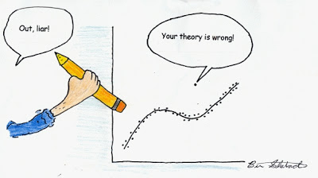